[GitHub](https://github.com/Janssena/DeepCompartmentModels.jl)[](https://github.com/Janssena/DeepCompartmentModels.jl/blob/main/tutorials/04-covariate-effects.qmd)

# Interpretable covariate effects

*Branch networks that keep each covariate's effect on a parameter readable*

```julia
using DeepCompartmentModels
using DataFrames, CSV
using CairoMakie
using Random
```

## Data

The warfarin data with weight, age and sex, as in the mixed-effects tutorial:

```julia
warfarin = DataFrame(CSV.File(joinpath(pkgdir(DeepCompartmentModels), "data", "warfarin.csv")))
warfarin = warfarin[warfarin.DVID .== 1, :]

function make_individual(g)
    covariates = Float32[g.WEIGHT[1], g.AGE[1], g.SEX[1]]
    doses = Matrix{Float32}(g[g.MDV .== 1, [:TIME, :DOSE, :RATE, :DURATION]])
    obs = g[g.MDV .== 0, :]
    return Individual(g.ID[1], covariates, obs.TIME, obs.DV, generate_dosing_callback(doses))
end

population = Population([make_individual(g) for g in groupby(warfarin, :ID)])
length(population)
```

```
32
```

## A branch network

The parameters of `one_comp_abs!` are `[kₐ, CL, V]`. We let weight act on clearance and volume, and age and sex on clearance only; absorption gets no covariate and stays at a fixed typical value.

```julia
ann = Lux.Chain(
    Normalize(Float32[100, 100, 1]),                      # scale the three covariates to [0, 1]
    Lux.BranchLayer(                                      # one branch per covariate
        MultiHeadedBranch(1, 6, 2; activation = Lux.swish),   # weight, one head each for CL and V
        SingleHeadedBranch(2, 6; activation = Lux.swish),     # age
        SingleHeadedBranch(3, 6; activation = Lux.swish),     # sex
    ),
    Combine(3, 1 => [2, 3], 2 => [2], 3 => [2]),          # 3 outputs; branch i acts on these outputs
    Lux.WrappedFunction(x -> x .* Float32[1, 0.2, 10]),   # typical values: kₐ, CL, V
)
```

```
Chain(
    layer_1 = Normalize(lower = Float32[0.0, 0.0, 0.0], upper = Float32[100.0, 100.0, 1.0]),
    layer_2 = BranchLayer(
        layer_1 = Chain(
            layer_1 = SelectDim(dim = static(1), index = static(1)),
            layer_2 = ReshapeLayer(output_dims = (1, :)),
            layer_3 = Dense(1 => 6, swish),       # 12 parameters
            layer_4 = Parallel(
                connection = vcat,
                layer_(1-2) = Dense(6 => 1, softplus),  # 14 (7 x 2) parameters
            ),
        ),
        layer_2 = Chain(
            layer_1 = SelectDim(dim = static(1), index = static(2)),
            layer_2 = ReshapeLayer(output_dims = (1, :)),
            layer_3 = Dense(1 => 6, swish),       # 12 parameters
            layer_4 = Dense(6 => 1, softplus),    # 7 parameters
        ),
        layer_3 = Chain(
            layer_1 = SelectDim(dim = static(1), index = static(3)),
            layer_2 = ReshapeLayer(output_dims = (1, :)),
            layer_3 = Dense(1 => 6, swish),       # 12 parameters
            layer_4 = Dense(6 => 1, softplus),    # 7 parameters
        ),
    ),
    layer_3 = Combine{Float32, Tuple{Pair{Int64, Vector{Int64}}, Pair{Int64, Vector{Int64}}, Pair{Int64, Vector{Int64}}}}(3, (1 => [2, 3], 2 => [2], 3 => [2])),
    layer_4 = WrappedFunction(#5),
)         # Total: 64 parameters,
          #        plus 24 states.
```

- `SingleHeadedBranch(i, n)` is a one-hidden-layer network on covariate `i` with `n` neurons and a softplus output, so it returns a positive multiplier. Keeping a branch to one or two covariates is what makes it readable.
- `MultiHeadedBranch(i, n, heads)` shares the hidden layer but has an independent output head per target. A branch must produce one row for every output it feeds, so weight, which acts on both `CL` and `V`, needs two heads. Age and sex act on one output each.
- `Combine(out_dim, branch => [outputs]...)` routes branches to outputs. Branches that point at the same output are multiplied. An output with no branch is `1`, so `kₐ` is just the typical value from the last layer.
- Branch layers read the covariates of a *matrix* (one column per individual), so use them with populations.

```julia
problem = ODEProblem(one_comp_abs!, zeros(Float32, 2), (-0.1f0, 1f0); dt = 0.01f0)
model = DCM(problem, ann; target = 2)
ps, st = setup(SSE(), Random.Xoshiro(1), model)
SSE()(model, population, ps, st)
```

```
5576.6035f0
```

## Fitting

```julia
function train(objective, model, population, ps, st; epochs, lr)
    opt_state = Optimisers.setup(Optimisers.Adam(lr), ps)
    losses = Float32[]
    for _ in 1:epochs
        ∇ = gradient(objective, model, population, ps, st)
        opt_state, ps = Optimisers.update(opt_state, ps, ∇)
        push!(losses, objective(model, population, ps, st))
    end
    return ps, losses
end

ps, losses = train(SSE(), model, population, ps, st; epochs = 300, lr = 0.01f0)
losses[[1, 100, 200, 300]]
```

```
4-element Vector{Float32}:
 5299.0547
 1040.9056
  999.51404
  988.38794
```

## Reading the covariate effects

Each branch is an ordinary Lux layer inside the chain, so its effect can be evaluated on a grid of covariate values. The helper below runs one branch over the whole range of its covariate and divides by the output at a reference value (the `anchor`), so that the effect is `1` at the anchor and `1.3` where the branch output is 30 % higher. The package also exports `interpret_branch` for this purpose, but it does not work with current Lux versions (see Status and limitations).

```julia
function covariate_effect(ann, ps_theta, st_theta, idx, anchor; upper)
    branch = ann.layers.layer_2.layers[idx]            # the branch layer of covariate `idx`
    ps_b, st_b = ps_theta.layer_2[idx], st_theta.layer_2[idx]
    # a branch reads row `idx` of a (covariates × samples) matrix
    run(v) = first(branch(vcat(zeros(Float32, idx - 1, length(v)), reshape(Float32.(v), 1, :),
                               zeros(Float32, 3 - idx, length(v))), ps_b, st_b))
    x = 0:0.01:1                                        # the normalised covariate
    return x .* upper, run(x) ./ run([anchor / upper])
end

x_weight, effect_weight = covariate_effect(ann, ps.theta, st.theta, 1, 70f0; upper = 100f0)
x_age, effect_age = covariate_effect(ann, ps.theta, st.theta, 2, 50f0; upper = 100f0)

size(effect_weight), size(effect_age)
```

```
((2, 101), (1, 101))
```

The weight branch has two heads, so `effect_weight` has a row for the effect on clearance and a row for the effect on volume.

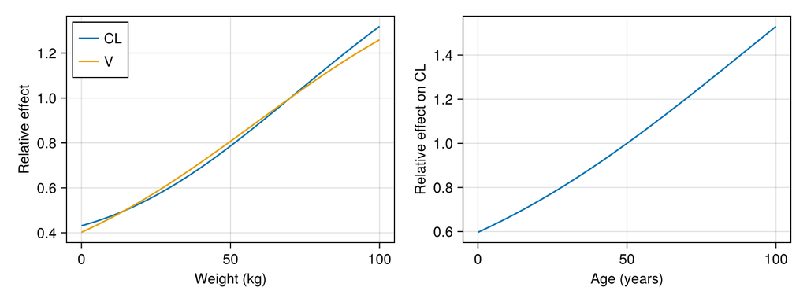

```julia
fig = Figure(size = (800, 300))
ax1 = Axis(fig[1, 1]; xlabel = "Weight (kg)", ylabel = "Relative effect")
lines!(ax1, x_weight, effect_weight[1, :]; label = "CL")
lines!(ax1, x_weight, effect_weight[2, :]; label = "V")
axislegend(ax1; position = :lt)
ax2 = Axis(fig[1, 2]; xlabel = "Age (years)", ylabel = "Relative effect on CL")
lines!(ax2, x_age, vec(effect_age))
fig
```

The curves cover 0 to the upper bound given to `Normalize`. Check the range of the data before reading the ends of a curve, since the network was only fitted where there are patients:

```julia
extrema(get_x(population)[1, :]), extrema(get_x(population)[2, :])
```

```
((40.0f0, 102.0f0), (21.0f0, 63.0f0))
```

Note

Because each covariate has an independent branch, the model is *multiplicative* across covariates: the effect of age on clearance is the same at every weight. That is the price of interpretability. A fully connected network can capture interactions but cannot be summarised in one plot per covariate.